# OSTA5003 Project Phase 1 Report

Authors

Yawei XI (550827289)

Yifeng LIN (560316872)

## Introduction

The modern music industry relies heavily on digital streaming platforms, where algorithms continuously analyze massive amounts of audio data to classify, recommend, and organize content. One of the fundamental challenges in this domain is accurately categorizing music into distinct genres based on its acoustic properties. This project focuses on the analysis of the Spotify Tracks dataset[^1], which contains 114,000 observations across 114 unique genres. The primary objective of this project is to build and evaluate a robust classification model capable of predicting the musical genre of a track using its continuous audio features, such as danceability, energy, acousticness, and tempo.

## Problem Statement

This project is a supervised multiclass classification problem aiming to predict the track_genre (114 categories) of Spotify tracks using audio features. Accurately mapping objective acoustic measurements to subjective genres is challenging but essential for modern automated music recommendation systems.  
**Potential Challenges:**

- Feature Correlation: Features like energy and loudness are highly correlated.
- Data Distributions: Features like speechiness are heavily right-skewed.
- Overlapping Classes: Differentiating 114 acoustically similar genres is difficult.

## Dataset Description

The dataset contains 114,000 samples and 21 columns (features). The columns consist of a mix of numeric and categorical data. Numeric features include continuous variables such as danceability, energy, loudness, speechiness, acousticness, instrumentalness, liveness, valence, tempo, duration_ms, and popularity. Categorical features include text strings such as track_id, artists, album_name, track_name, explicit, and the target variable track_genre.

## Initial EDA

In this section, the necessary libraries and the dataset are loaded. Then the exploratory data analysis (EDA) is performed to understand the basic structure and characteristics of the data.

```r
library(tidyverse)
library(corrplot)
library(visdat)

spotify_df <- read.csv("dataset/spotify-tracks-dataset.csv")
```

#### Dataset Overview

The following demonstrates the scale of the dataset and the sample data of the features (Danceability, Energy, Loudness, Speechiness, Acousticness, Instrumentalness, Liveness, Valence, Tempo, etc).

```r
glimpse(spotify_df)
```

```
Rows: 114,000
Columns: 21
$ X                <int> 0, 1, 2, 3, 4, 5, 6, 7, 8, 9, 10, 11, 12, 13, 14, 15,…
$ track_id         <chr> "5SuOikwiRyPMVoIQDJUgSV", "4qPNDBW1i3p13qLCt0Ki3A", "…
$ artists          <chr> "Gen Hoshino", "Ben Woodward", "Ingrid Michaelson;ZAY…
$ album_name       <chr> "Comedy", "Ghost (Acoustic)", "To Begin Again", "Craz…
$ track_name       <chr> "Comedy", "Ghost - Acoustic", "To Begin Again", "Can'…
$ popularity       <int> 73, 55, 57, 71, 82, 58, 74, 80, 74, 56, 74, 69, 52, 6…
$ duration_ms      <int> 230666, 149610, 210826, 201933, 198853, 214240, 22940…
$ explicit         <chr> "False", "False", "False", "False", "False", "False",…
$ danceability     <dbl> 0.676, 0.420, 0.438, 0.266, 0.618, 0.688, 0.407, 0.70…
$ energy           <dbl> 0.4610, 0.1660, 0.3590, 0.0596, 0.4430, 0.4810, 0.147…
$ key              <int> 1, 1, 0, 0, 2, 6, 2, 11, 0, 1, 8, 4, 7, 3, 2, 4, 2, 1…
$ loudness         <dbl> -6.746, -17.235, -9.734, -18.515, -9.681, -8.807, -8.…
$ mode             <int> 0, 1, 1, 1, 1, 1, 1, 1, 1, 1, 1, 1, 0, 1, 1, 1, 1, 0,…
$ speechiness      <dbl> 0.1430, 0.0763, 0.0557, 0.0363, 0.0526, 0.1050, 0.035…
$ acousticness     <dbl> 0.0322, 0.9240, 0.2100, 0.9050, 0.4690, 0.2890, 0.857…
$ instrumentalness <dbl> 1.01e-06, 5.56e-06, 0.00e+00, 7.07e-05, 0.00e+00, 0.0…
$ liveness         <dbl> 0.3580, 0.1010, 0.1170, 0.1320, 0.0829, 0.1890, 0.091…
$ valence          <dbl> 0.7150, 0.2670, 0.1200, 0.1430, 0.1670, 0.6660, 0.076…
$ tempo            <dbl> 87.917, 77.489, 76.332, 181.740, 119.949, 98.017, 141…
$ time_signature   <int> 4, 4, 4, 3, 4, 4, 3, 4, 4, 4, 4, 3, 4, 4, 4, 3, 4, 4,…
$ track_genre      <chr> "acoustic", "acoustic", "acoustic", "acoustic", "acou…
```

The genre column contains 114 unique categories.

```r
length(unique(spotify_df$track_genre))
```

```
[1] 114
```

#### Missing Values

The dataset contains no missing values, as confirmed by the following visualization.

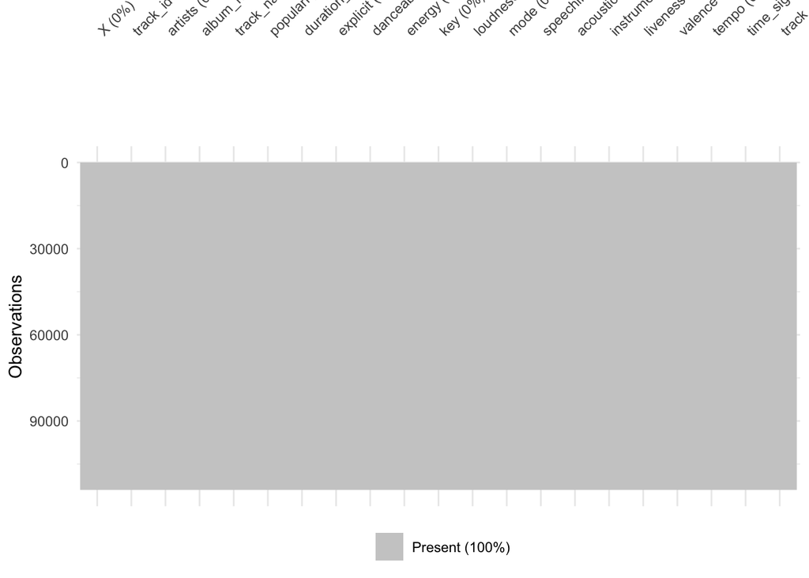

```r
vis_miss(spotify_df, warn_large_data = FALSE)
```

#### Target Imbalance

Analysis of the target variable, track_genre, reveals that there are 114 distinct categories. Each category contains exactly 1,000 sample instances. The data is perfectly balanced across all classes.

```r
genre_counts <- spotify_df |> count(track_genre, sort = TRUE)

head(genre_counts)
```

```
  track_genre    n
1    acoustic 1000
2    afrobeat 1000
3    alt-rock 1000
4 alternative 1000
5     ambient 1000
6       anime 1000
```

```r
tail(genre_counts)
```

```
    track_genre    n
109       tango 1000
110      techno 1000
111      trance 1000
112    trip-hop 1000
113     turkish 1000
114 world-music 1000
```

#### Feature Distributions

Danceability exhibits an approximately normal distribution, whereas speechiness is severely right-skewed.

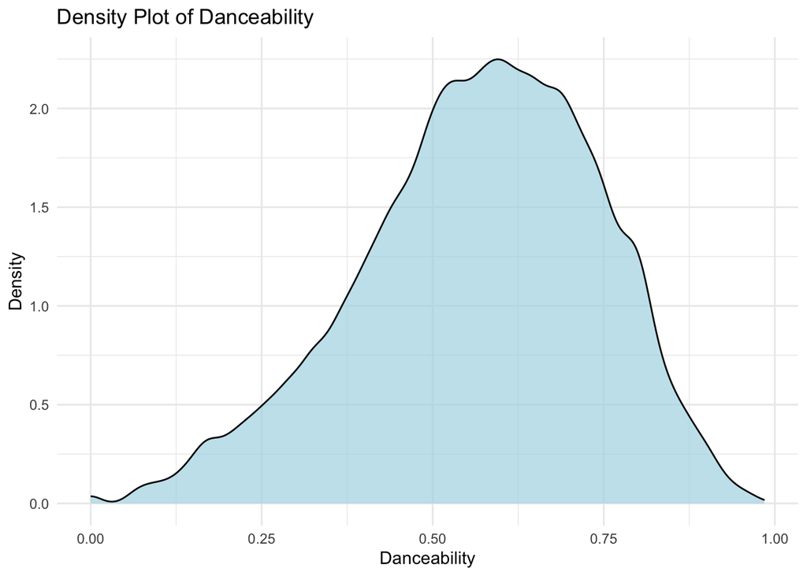

```r
dp_danceability <- ggplot(spotify_df, aes(x = danceability)) +
                   geom_density(fill = "lightblue", alpha = 0.7) +
                   theme_minimal() +
                   labs(title = "Density Plot of Danceability", x = "Danceability", y = "Density")
print(dp_danceability)
```

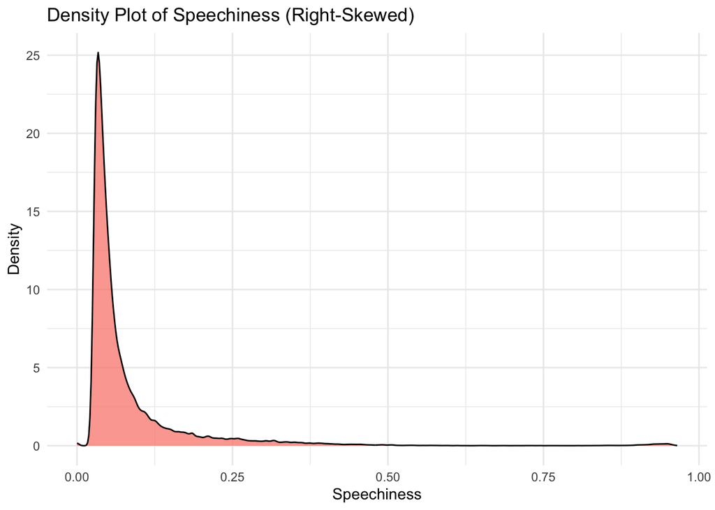

```r
dp_speechiness <- ggplot(spotify_df, aes(x = speechiness)) +
                  geom_density(fill = "salmon", alpha = 0.7) +
                  theme_minimal() +
                  labs(title = "Density Plot of Speechiness (Right-Skewed)", x = "Speechiness", y = "Density")
print(dp_speechiness)
```

#### Feature Correlation

The heatmap illustrates the correlation between numeric features. Notably, energy and loudness exhibit a very high positive correlation.

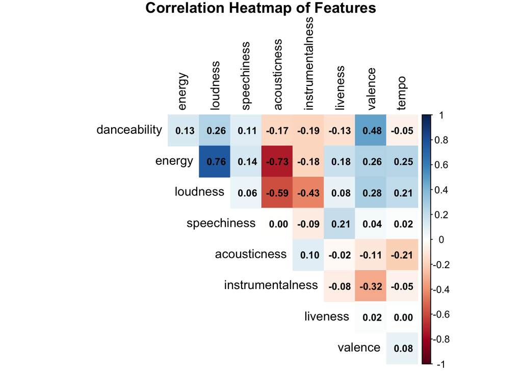

```r
numeric_features <- spotify_df |> select(danceability, energy, loudness, speechiness, acousticness, instrumentalness, liveness, valence, tempo)
cor_matrix <- cor(numeric_features, use = "complete.obs")

corrplot(cor_matrix,
         method = "color",
         type = "upper",
         addCoef.col = "black",
         diag = FALSE,
         tl.col = "black",
         number.cex = 0.8,
         title = "Correlation Heatmap of Features",
         mar = c(0,0,1,0))
```

## Model Selection

**Random Forest** is selected as the model for this classification task. This tree-based ensemble is highly effective at capturing the complex, non-linear relationships between features and subjective musical genres. Given the dataset’s complexity, comprising 114,000 samples across 114 distinct target classes, Random Forest is well-suited. It is robust against highly correlated features (such as the high correlation between energy and loudness) and effectively mitigates overfitting through its randomized ensemble approach, making it an optimal choice for this complex dataset.

## Evaluation Metrics

To comprehensively evaluate the performance of our multiclass classification models across 114 genres, the following metrics will be applied:

- **Accuracy:** the overall accuracy will be calculated to measure the total proportion of correctly predicted tracks across the entire dataset. It serves as a straightforward, high-level performance indicator.
- **F1-Score:** F1-Score will be caculated for each of the 114 genres and then takes the average. This ensures that the model’s performance on every single genre is evaluated equally.
- **Confusion Matrix:** a confusion matrix will be generated to visualize the model’s predictions against the true labels.

## Project Plan

- **Week 1: Data Preparation**  
  Task: Finalize data cleaning and execute feature engineering.  
  Yawei XI: Responsible for feature engineering, including applying log transformations to skewed numeric features.  
  Yifeng LIN: Responsible for data cleaning.
- **Week 2: Modeling & Optimization**  
  Task: Train Random Forest. Conduct hyperparameter tuning and extract feature importance scores.  
  Yawei XI: Responsible for conducting hyperparameter tuning and extracting feature importance scores.  
  Yifeng LIN: Responsible for building and training the initial Random Forest models.
- **Week 3: Evaluation & Analysis**  
  Task: Evaluate model results using the defined evaluation metrics and generate all necessary performance visualizations.  
  Yawei XI: Responsible for computing and analyzing the core evaluation metrics.  
  Yifeng LIN: Responsible for generating performance visualizations, specifically the Confusion Matrix for error analysis.
- **Week 4: Final Deliverables**  
  Task: Compile the findings into the final written report and prepare the slide deck for the final presentation.  
  Yawei XI: Responsible for drafting, structuring, and formatting the final written report.  
  Yifeng LIN: Responsible for designing and preparing the presentation slide deck.  
  Both members will conduct a final review.

## Footnotes

[^1]: [Spotify Tracks Dataset](https://www.kaggle.com/datasets/maharshipandya/-spotify-tracks-dataset) from Kaggle. This dataset is licensed under [Open Data Commons Open Database License (ODbL) v1.0](https://opendatacommons.org/licenses/odbl/1-0/).